# ESM206 Final

Anthony Luna

# Task 1. Predicting penguin mass

## A. Visualization of penguin species, sex, flipper length, and body mass

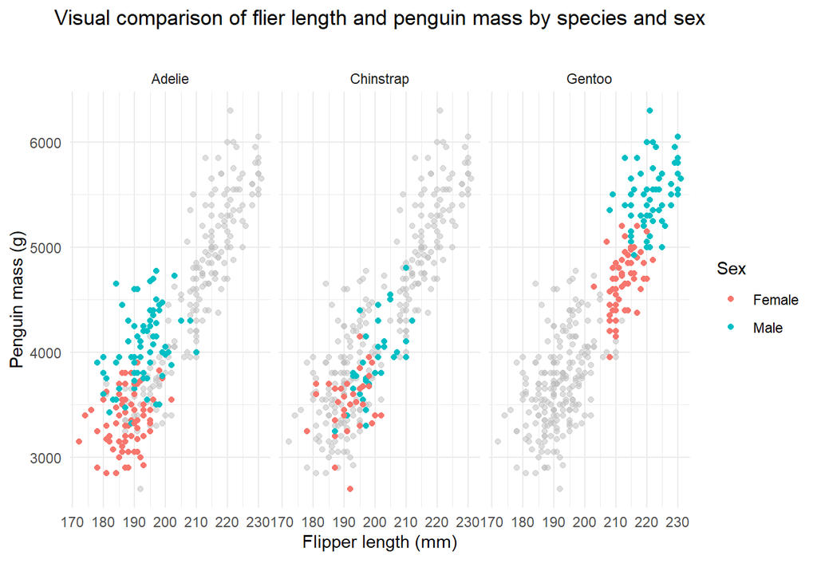

**Figure 1:** Penguin mass and flipper length ploted for each species. Points are also distinguished by sex using red and blue colors.

## B. Observations of visualization

- All three species show a clustering of points based on sex, where the male penguins are generally larger by mass and somewhat longer by flipper length.
- The Gentoo cluster is apparently well distinguished from Adelie and Chinstrap penguins with regard to flipper length and mass.
- The Adelie and Chinstrap penguins are apparently less well distinguished from each other with regard to mass, but somewhat distinguished by flipper length.

## C. Regression Models

**Table 1:** Linear Regression statistics for all predictor variable permutations. Highlighted row has been selected as best model for weight prediction based off of lowest AIC value which indicates the best balance between complexity and fit of the model.

| relationship | r.squared | adj.r.squared | sigma | statistic | p.value | df | logLik | AIC | BIC | deviance | df.residual | nobs |
| --- | --- | --- | --- | --- | --- | --- | --- | --- | --- | --- | --- | --- |
| Sex:Species:Flipper | 0.867 | 0.865 | 295.565 | 534.024 | <0.00001 | 4 | -2364.387 | 4740.774 | 4763.623 | 28653568 | 328 | 333 |
| Sex:Species | 0.847 | 0.845 | 316.608 | 606.143 | <0.00001 | 3 | -2387.797 | 4785.594 | 4804.634 | 32979185 | 329 | 333 |
| Sex:Flipper | 0.806 | 0.805 | 355.883 | 684.803 | <0.00001 | 2 | -2427.242 | 4862.484 | 4877.717 | 41795374 | 330 | 333 |
| Species:Flipper | 0.787 | 0.785 | 373.284 | 405.281 | <0.00001 | 3 | -2442.633 | 4895.267 | 4914.307 | 45843144 | 329 | 333 |
| Flipper | 0.762 | 0.761 | 393.343 | 1060.295 | <0.00001 | 1 | -2461.073 | 4928.146 | 4939.570 | 51211963 | 331 | 333 |
| Species | 0.674 | 0.673 | 460.795 | 341.895 | <0.00001 | 2 | -2513.273 | 5034.546 | 5049.778 | 70069447 | 330 | 333 |
| Sex | 0.181 | 0.178 | 729.981 | 72.961 | <0.00001 | 1 | -2666.979 | 5339.957 | 5351.382 | 176380769 | 331 | 333 |

## E. Adjusted-R<sup>2</sup>

For the selected model, the adjusted R<sup>2</sup> is 0.865, which means that 86.5% of the variance is in penguin weight is explained by species, sex, and flipper length.

## F. Coefficient Interpretation

- sexMale (coef = 530.381): Given all other predictor variables are fixed, if the sex is Male, the weight of the penguin will be 530.381 g greater than if the penguin was female.
- short_speciesChinstrap (coef = -87.634): Given all other predictor variables are fixed, if the species is Chinstrap, the weight of the penguin will be 87.634 g less than if the penguin was the reference species - Adelie.
- short_speciesGentoo (coef = 836.26): Given all other predictor variables are fixed, if the species is Gentoo, the weight of the penguin will be 836.26 g greater than if the penguin was the reference species - Adelie.
- flipper_length_mm (coef = 20.025): Given all other predictor variables are fixed, the weight of the penguin will increase by 20.025 g for every 1 mm increase in flipper length.

## G. Predictions using model

**Table 2:** Predicted penguin weights based off sex, species, and flipper length using the selected model.

| Sex | Species | Flipper Length (mm) | Predicted Weights (g) |
| --- | --- | --- | --- |
| Female | Chinstrap | 195 | 3451.41 |
| Male | Adelie | 205 | 4269.67 |
| Male | Gentoo | 220 | 5406.31 |

# Task 2. Smoking defects on baby birth weight

## A. Table showing proportion of birth weights

**Table 3:** Birth weight proportions for children of mothers who were smokers and non-smokers during pregnancy where low birth weight is considered to be less than 5 lb 8 oz.

| Birth weight | Non-smoker | Smoker |
| --- | --- | --- |
| Normal | 656 (91%) | 72 (86%) |
| Low | 62 (9%) | 12 (14%) |

## B. Statistical analysis of proportions

There is not a significant difference between the proportion of low birth weight for children of mothers who are smokers or non-smokers (p value = 0.135).

## C. Discussion of survey methods

The format of the question does not specify the amount that the mother smoked, only that they smoked at all during pregnancy. It would be more appropriate to use an ordinal variable to ask how much the mother smoked during pregnancy, e.g. “No smoking”, “1-5 cigarettes”, “6-10 cigarettes”, “11-20 cigarettes”, or “20+ cigarettes”.

# Task 3. Visualizing UCSB campus profiles

## A. Goal

The change in diversity of UCSB undergraduates and graduates was compared from 2008 to 2017. Data from 2018 was omitted due to incomplete counts. Undergraduate and graduate proportions over time were plotted separately, and student ethnicity were grouped by white and non-white with ‘Unknown’ ethnicity removed to avoid over representation in either group.

## B. Visualization

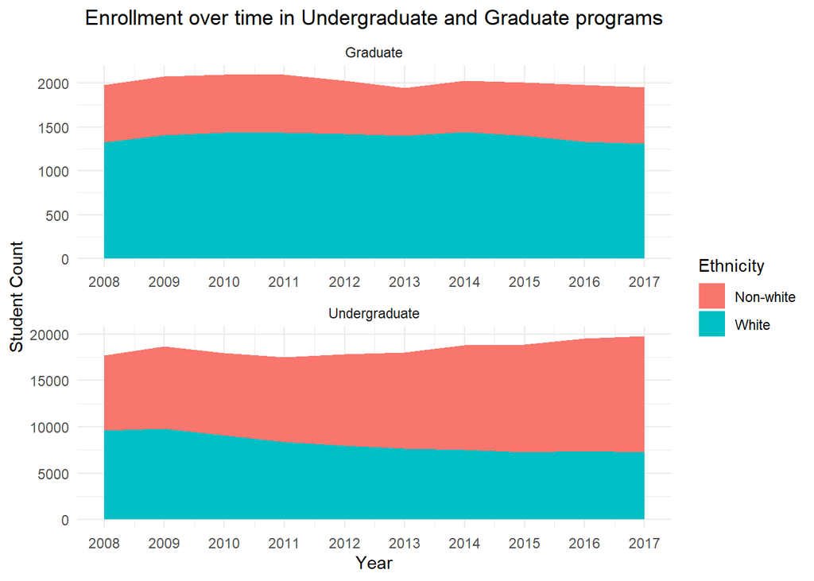

**Figure 2:** Total counts of students enrolled in graduate and undergraduate programs distinguished by ethnicity. Ethnicties were grouped by white and non-white. Unknown ethnicities were excluded to avoid over representation in either group.

# Task 4. Purple urchins on the Santa Barbara coast

## A. Urchin size summary statistics

**Table 4:** Summary statistics of urchin size (cm) across 5 different locations in control treatments where kelp was not removed.

| Site | Mean (cm) | Count | Standard Deviation (± cm) | Standard Error (± cm) |
| --- | --- | --- | --- | --- |
| Arroyo Quemado | 4.57 | 3185 | 1.04 | 0.02 |
| Carpinteria | 4.17 | 3430 | 1.13 | 0.02 |
| Isla Vista | 4.25 | 1601 | 0.94 | 0.02 |
| Mohawk | 5.28 | 3510 | 1.14 | 0.02 |
| Naples | 4.05 | 3219 | 1.11 | 0.02 |

## B. Exploratory data visualization

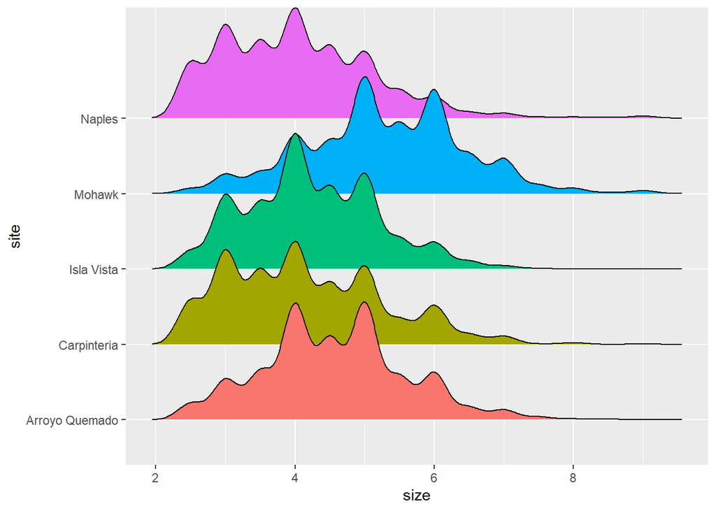

**Figure 3:** Distribution of urchin length (cm) by site

- Mohawk generally has a higher size distribution in comparison to the other sites.
- This distribution plot points our that the precision of size measurements are 0.5 cm based on peaks being present at each 0.5 cm break.

## C. Differences in size by site

Mean sizes differed significantly between all groups except between Isla Vista and Carpinteria (one-way ANOVA with post-hoc Tukey’s HSD (F(4,14 940)=692.99, p < 0.001). The effect size of these differences are seen in the table below. As observed in part A, the size of urchins at Mohawk have a significant effective difference in size compared to the other sites, except for Arroyo Quemado where the difference is medium in effective size. The effective size is between small and negligible for the rest of the sites compared.

**Table 5:** Cohen’s d for differences in mean urchin size between each site. All combinations of sites included except for Isla Vista-Carpinteria due to lack of statistical significance. Values greater than 0.8, 0.5, or 0.2 are considered to have large, medium, and small effective size differences respectively. Values less than 0.2 are considered to have negligible differences in mean size.

| Sites Compared | Cohen’s d |
| --- | --- |
| Naples-Mohawk | 1.09 |
| Mohawk-Carpinteria | 0.98 |
| Mohawk-Isla Vista | 0.95 |
| Mohawk-Arroyo Quemado | 0.65 |
| Naples-Arroyo Quemado | 0.49 |
| Carpinteria-Arroyo Quemado | 0.37 |
| Arroyo Quemado-Isla Vista | 0.32 |
| Naples-Isla Vista | 0.19 |
| Naples-Carpinteria | 0.10 |